# Statistics with R

Data Visualization

Zhuanghua Shi (Strongway)

14 May, 2019

# Last week: Import/Export Data

R can import and export many types of data. Most often format used are text, csv and excel files.

# Import txt/csv files

- Read tabular data into R

`read.table(file, header = FALSE, sep = "", dec = ".")`

- Read “comma separated value” files (“.csv”)

`read.csv(file, header = TRUE, sep = ",", dec = ".", ...)`

- Or use read.csv2: variant used in countries that use a comma as decimal point and a semicolon as field separator.

`read.csv2(file, header = TRUE, sep = ";", dec = ",", ...)`

- Read TAB delimited files

`read.delim(file, header = TRUE, sep = "\t", dec = ".", ...)` `read.delim2(file, header = TRUE, sep = "\t", dec = ",", ...)`

# Import txt/csv files using readr

- `tidyverse` includes the package `readr`, a faster and friendly way to read table-like files.
  - `read_csv()`: comma separated (CSV) files
  - `read_tsv()`: tab separated files
  - `read_delim()`: general delimited files
  - `read_fwf()`: fixed width files
  - `read_table()`: tabular files where colums are separated by white-space.
  - `read_log()`: web log files
- `readr` provides consistence column specification (the most significant feature differs from the classical functions)

# Import example

- read the data `exp1.csv` and show its head

```r
data = read_csv('data/exp1.csv')
head(data, n = 3)
```

```
## # A tibble: 3 x 8
##   target  setsize dyn     resp    rt   sub   exp correct
##   <chr>     <int> <chr>  <int> <dbl> <int> <int>   <int>
## 1 Absent       12 Static     2 2.58      1     1       1
## 2 Absent        8 Static     2 0.936     1     1       1
## 3 Present      16 Static     1 0.795     1     1       1
```

# Export/save Data

- Exporting data is similar to importing data. You can simply change the above mentioned functions from `read*` to `write*`.

> `write.csv()`, `write.csv2()`, `write_csv()`
- Import and export excel files requires additional package `readxl`.
- Save data for R Data Format: RDS

> Save an object to a file

> saveRDS(object, file = “my_data.rds”)

> Restore the object

> readRDS(file = “my_data.rds”)

# Visualization with `ggplot2`

- Visualization is a critical step for explorative data analysis (EDA)

# `ggplot` grammar

# An example

Note, we’ve learned ‘pipe’ function `%>%`. First, we summarize the mean data, and then visualize them with line plots.

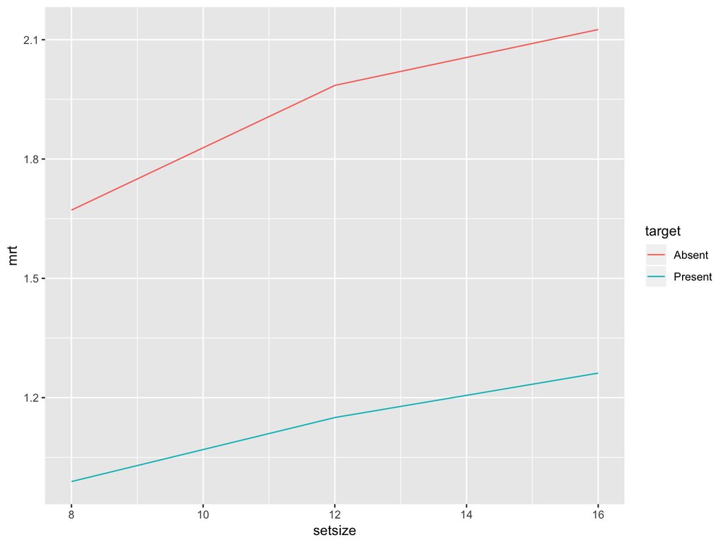

```r
data %>% group_by(target, setsize) %>%
  summarise(mrt = mean(rt)) %>%
  ggplot(data = .) +
    geom_line(mapping = aes(x = setsize, y = mrt, color = target ))
```

# Excercises

1. use data `mpg` from ggplot2 package, and inspect the data structure.
2. produce a scatterplot with x = displ, and y = hwy.
3. Make a scatterplot of hwy vs cyl

# Aesthetic mappings

An aesthetic is a visual property of the objects in your plot. Aesthetics includes:

- size
- shape
- color
- transparency (alpha)

You can display a point in different ways by changing the values of its aesthetic properties.

# An example using aesthetic

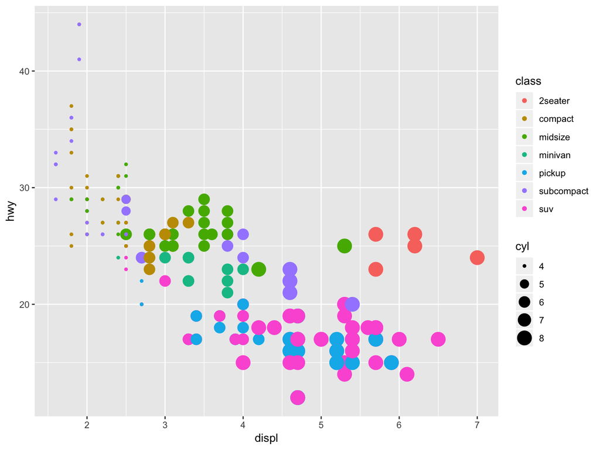

Try to change the size to class, and see what happens…

# Aesthetic mappings

For each aesthetic, you use `aes()` to associate the name of the aesthetic with a variable to display.

You can *set* the aesthetic properties of your geom manually:

- It should be outside `aes()`
  - Color : a string
  - Size : a value in mm
  - Shape : a number represents a shape (see below)

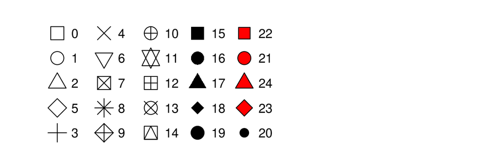

# Excercises

1. Scatter plot of data `mpg` with `x= displ, y = hwy` with blue points

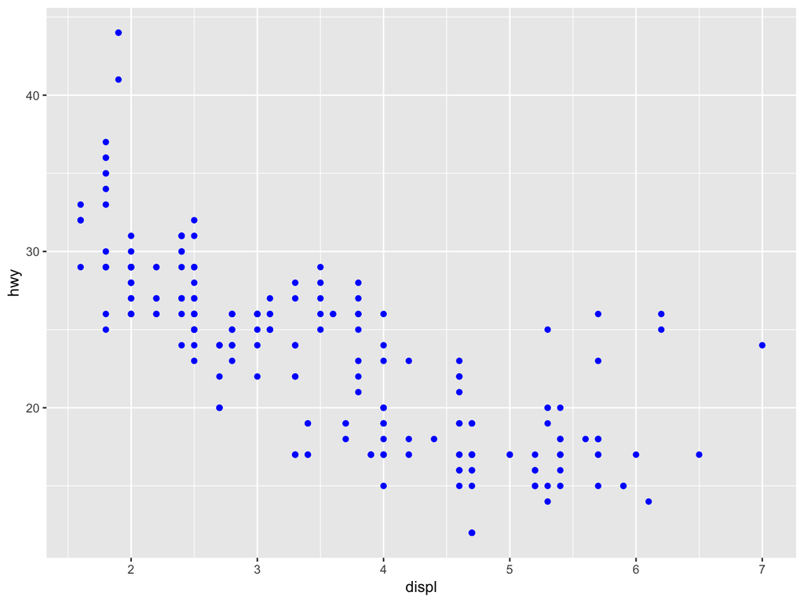

2. try to move `color = 'blue'` into `aes()`, and see what happens…
3. please change the shape to square
4. try `aes(color = displ < 5)` and see what happens…

# Manually specify aesthetic

By default, `ggplot2` takes care of the rest (which color maps to which group/condition, etc.). But you can change the aesthetic mapping manually.

This calls **scale**

- scale_*_manual(values = c()): map aesthetic manually
- scale_*_continuous(): map cont’ values to visual ones
- scale_*_discrete(): map discrete values to visual ones
- scale_x_log10()
- scale_x_reverse()
- scale_x_sqrt()

# common problem in plotting

- ggplot using `+` for layering.

> If you miss the last part, R doesn’t think you’ve typed a complete expression and it’s waiting for you to finishe it. **ESCAPE to abort**.
- `+` in a wrong place.

> It has to come at the end of the line, **not** the start.

> If mappings are the same, you can move it to `ggplot()`.

# Some tipps

- Barplot by default only plots the counts. If you want to plot mean etc, you need to specify `stat = 'identity'`
- Multiple conditions in Barplot `position = 'dodge'`.
- Be aware of your type of data (category vs. continuous)
  - the data format will affect your graph. Using `factor()` or `as.numeric()` to convert your data type.
- `facet_*()` can be very helpful to examin individual participants
  - `facet_wrap()`
  - `facet_grid(A ~ B)`

# Excercises

1. Please load data from `exp1.csv`, and visualize mean data for individual subjects with a `facet_*()` function

# Geometric objects

## Five Named Graphs - The 5NG

- Scatterplots `geom_point()`
- linegraphs `geom_line()`
- histogram `geom_histogram()`
- Boxplot `geom_boxplot()`
- Barplots `geom_bar()`

ggplot2 provides over 30 geoms, such as

- geom_smooth()
- geom_area()
- geom_errorbar()
- geom_label()

Please see the cheetsheet for details.

Extension packages provides even more (see https://www.ggplot2-exts.org).

# Statitical transformations - Bar chart

By default, `geom_bar()` plot the count. Internally, ggplot first calculate the counts, and then plot. For example:

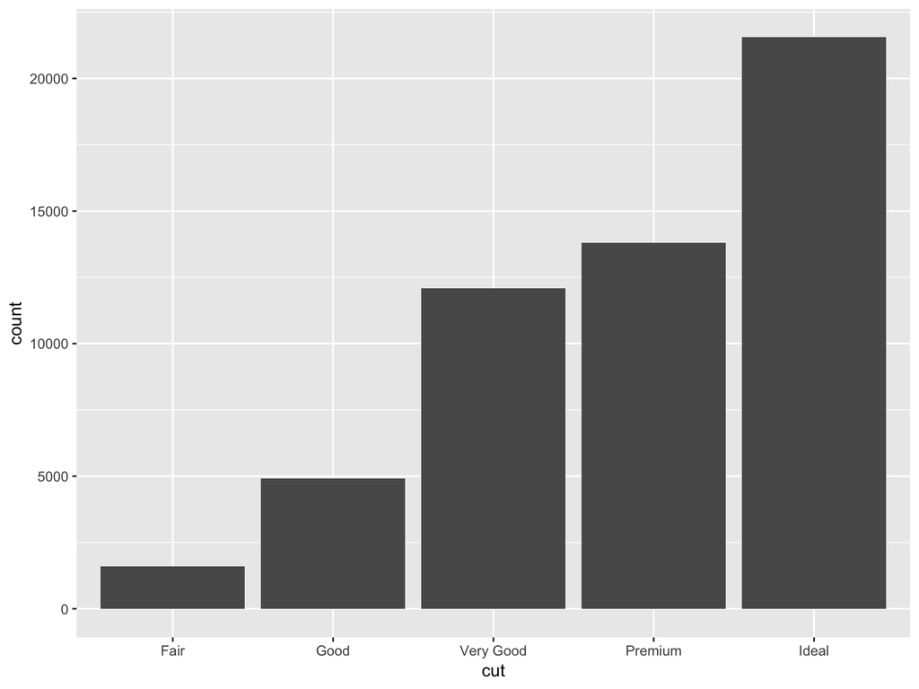

If you want to override the default ‘count’ mapping transformation, you can specify via `aes()`. For example, you may want to have internal variable ‘proportion’.

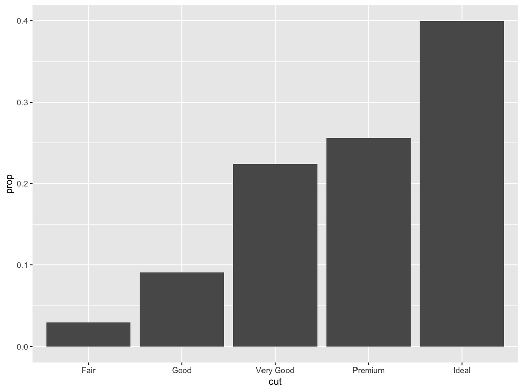

# Position adjustments

By default, bar plots stack bars one over another if you have a mapping to different conditions. For example:

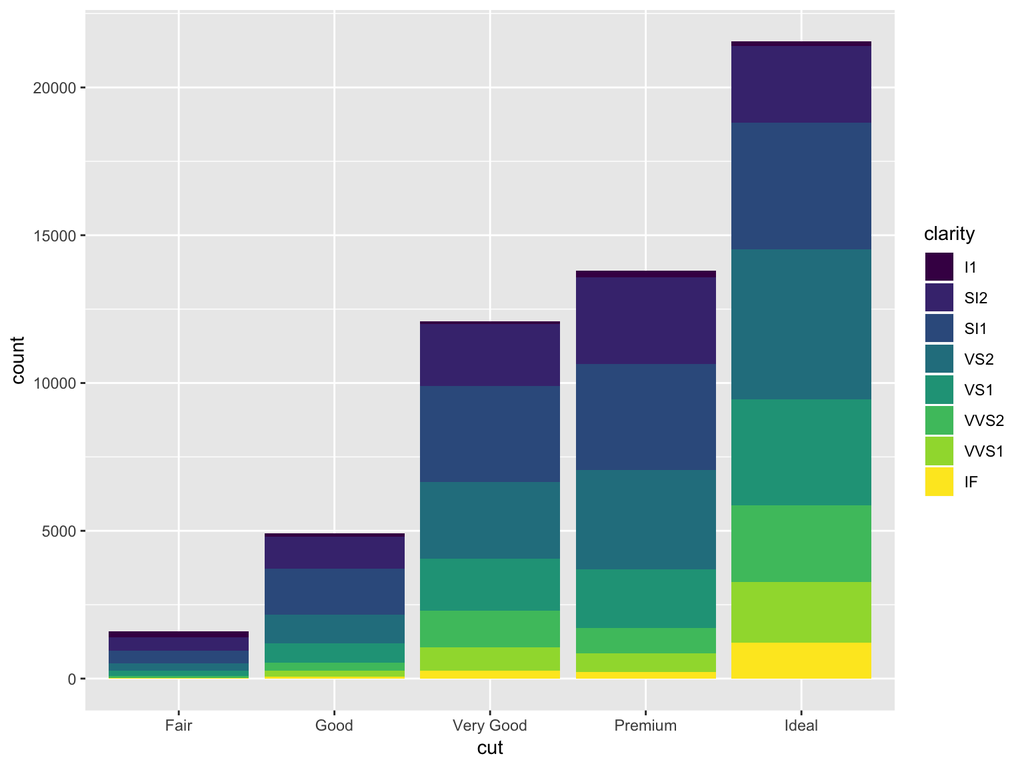

## position adjustment with `position` argument

Options:

- identity
- dodge (most useful one)
- fill
- jitter

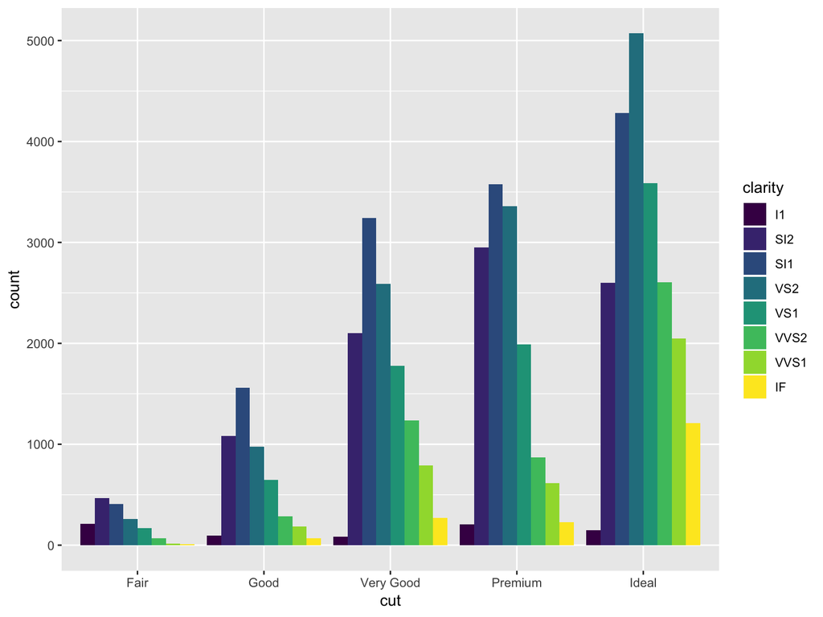

# Error bars - an example

- Error bars are common in APA figures.

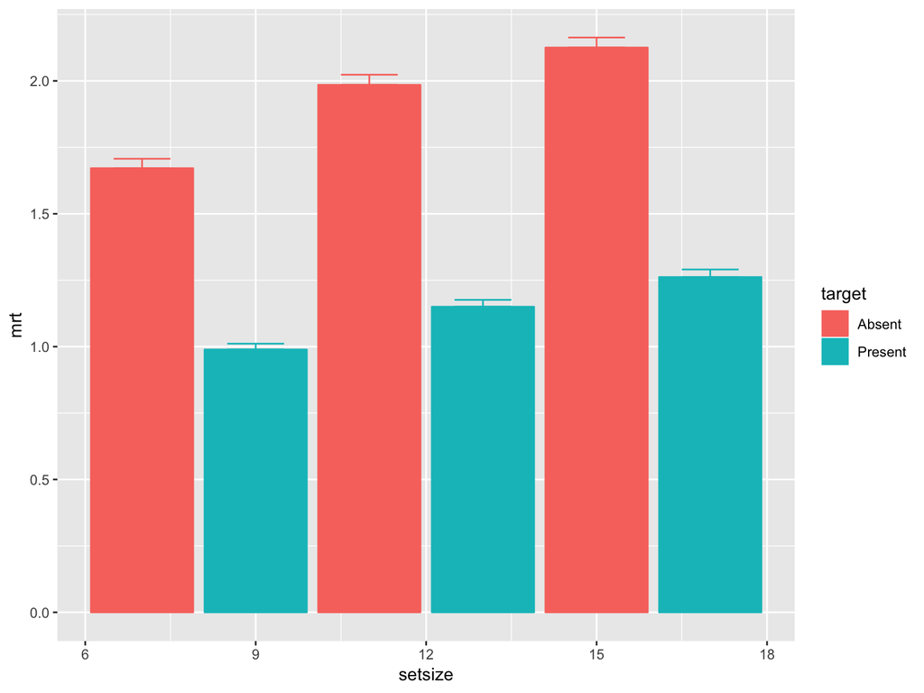

```r
pos <- position_dodge(width = 4)

data %>% group_by( setsize, target) %>%
  summarise(mrt = mean(rt), n = n(), se = sd(rt)/sqrt(n-1)) %>%
  ggplot(., aes(x = setsize, y = mrt, color = target, fill = target )) + geom_bar(stat = 'identity', position = pos) +   geom_errorbar(aes(ymin=mrt , ymax = mrt + se),  position = pos, width = 2)
```

# Excercises

- Produce the correct error bars for the dataset `exp1.csv`.